# Onset of Labor model training

Here we are building a model similar to the one of the OOL study but on the data of the drug assay study. The code is based on the one used for the OOL study.

## Paths

```r
setwd("/Users/jonasamar/Stabl/Drug Study/Rscripts")
OOL_path="/Users/jonasamar/Stabl/Drug Study/Onset of Labor csv"
drug_assay_path="/Users/jonasamar/Stabl/Drug Study/Drug assay csv"
```

## Libraries

```r
library(doSNOW)
library(parallel)
library(matrixStats)
library(zoo)
library(ggVennDiagram)
library(tidyverse)
library(readxl)
set.seed(2018)
```

## Importing and preprocessing data

Preprocessing function which: 1 - Remove features with proportion of NA above a certain threshold 2 - Replace remaining NA values with the median of the feature 3 - Remove features with standard deviation below a certain threshold

```r
preprocessing <- function(dataset, NA_threshold, std_threshold){
  prepro_data <- dataset
  cols <- colnames(dataset)
  # Removing columns with proportion of missing values above NA_threshold
  rm_cols <- c()
  for (col_name in cols[!cols %in% "ID"]){
    na_count <- sum(is.na(prepro_data[[col_name]]))
    if (na_count/length(prepro_data[[col_name]]) > NA_threshold){
      rm_cols[length(rm_cols)+1] <- col_name
    }
  }
  prepro_data <- prepro_data[,!colnames(prepro_data) %in% rm_cols]
  # Imputing missing values with median of the colum
  for (col_name in cols[!cols %in% "ID"]){
    median <- median(prepro_data[[col_name]], na.rm = TRUE)
    prepro_data[[col_name]][is.na(prepro_data[[col_name]])] <- median
  }
  # Removing columns with standard deviation below std_threshold
  keep_cols <- which(colSds(as.matrix(prepro_data[,-which(names(prepro_data) == "ID")]))>std_threshold)
  prepro_data <- prepro_data[,keep_cols]
  return(prepro_data)
}
```

Importing and preprocessing the data for DOS between DOS_inf and DOS_sup

```r
# DOS limits of the training data
DOS_inf=-120
DOS_sup=1
# all.simulated.data
load(paste0(OOL_path, "/immunome_noEGA_OOL_with_drugs.rda"))
# Outcomes
Yh <- read_csv(paste0(OOL_path, "/outcome_OOL.csv"), show_col_types = FALSE)
# CYTOF data
CYTOF <- read_csv(paste0(OOL_path, "/immunome_noEGA_pen_OOL.csv"), show_col_types = FALSE)
# Reorordering and filtering CYTOF data
data <- left_join(Yh, CYTOF, by="ID") %>% filter((DOS <= DOS_sup)&(DOS>=DOS_inf))
Yh <- data$DOS
CYTOF <- select(data, -DOS)
# Preprocessing
CYTOF <- preprocessing(CYTOF, 0.2, 0.)
# Patients Id
Id <- as.factor(str_extract(CYTOF[["ID"]], "(?<=P)\\d+"))
```

## Model

Helper function for predictive modeling and LOOCV Input arguments: X: data matrix with patients, and omics measurments on rows and columns, respectively. Y: response vector. foldid: patients index that is a unique id for all subjects corresponding to the same patient. i: the patient id that should be left out during the training process parm: parameters of the Lasso Output args, ret: a list of predictions on the training and test data with the coefficients of Lasso

The complete analysis was performed using a similar strategy but using parallel processing to optimize lambda, followed by a stack generalization layer as described in the article.

```r
xxx<-function(X, Y, foldid, i, parm, predict.simulated.data=FALSE)
{
  suppressMessages(library(randomForest, quietly = TRUE))
  suppressMessages(library(glmnet, quietly = TRUE))
  set.seed(2018+123*i)

  X <- X[, -which(colnames(X) == "ID")] # Removing the ID column

  iInd=which(foldid==unique(foldid)[i])
  if(length(iInd)<2){
    iInd=c(iInd, iInd)
  }
  if(parm$scale=='ALL'){
    X=scale(X)
  }
  if(parm$scale=='Patient')
  {
    for(ap in seq(length(unique(foldid))))
    {
      sclidx= which(foldid==unique(foldid)[ap])
      if(length(sclidx)>1)
        X[sclidx]=scale(X[sclidx], scale=F)
    }
    X=scale(X) #creates NA values for 10 features
    rm_columns <- which(colSums(is.na(X)) > 0) # Getting the columns that are removed
    original.X=X # Keeping a copy of X without any columns removed
    X=X[, complete.cases(t(X))] #we remove those features
  }

  # Calculate Spearman's rank correlation and p-value
  results <- vector("list", ncol(X))
  for (j in seq_len(ncol(X))) {
    res <- cor.test(X[, j], Y, method = "spearman", use = "pairwise.complete.obs", exact = FALSE)
    results[[j]] <- data.frame(colname = colnames(X)[j], pvalue = res$p.value)
  }

  # Combine results into a data frame
  pval_df <- bind_rows(results) %>%
                mutate(pvalue = as.numeric(pvalue))

  # Removing features with pvalue under a pval_threshold
  fiter.out.features <- pval_df[pval_df$pvalue >= parm$pval_threshold, "colname"]
  X <- X[,!(colnames(X) %in% fiter.out.features)]
  rm_columns <- c(setNames(match(fiter.out.features, colnames(original.X)), fiter.out.features), rm_columns)

  XX=X[-iInd,]
  YY=Y[-iInd]
  XT=X[iInd,]
  fld=as.numeric(foldid[-iInd])

  # Transforming the values of fld so that they range from 1 to 52 (avoiding one warning from glmet)
  fld[fld>=i]=fld[fld>=i]-1

  ret = list()

  # Removed columns
  ret$rm_cols <- rm_columns

  # LASSO 1SE
  cvglm = cv.glmnet(XX, YY,  standardize=F, alpha=1, foldid = fld)
  ret$p1 = predict(cvglm, XT, s='lambda.1se')
  ret$ptrain1 = predict(cvglm, XX, s='lambda.1se')
  ret$coef = coef(cvglm, s='lambda.1se')[-1]
  ret$model = cvglm

  # Elastic Net
  EN_cv = cv.glmnet(x = XX, y = YY, foldid = fld, alpha = parm$a)
  ret$EN_p1 = predict(EN_cv, XT, s=EN_cv$lambda.min)
  ret$EN_ptrain1 = predict(EN_cv, XX, s=EN_cv$lambda.min)
  ret$EN_coef = coef(EN_cv, s=EN_cv$lambda.min)[-1]

  # Ridge Regression
  ridge_cv = cv.glmnet(x = XX, y = YY, foldid = fld, alpha = 0)
  ret$ridge_p1 = predict(ridge_cv, XT, s=ridge_cv$lambda.min)
  ret$ridge_ptrain1 = predict(ridge_cv, XX, s=ridge_cv$lambda.min)
  ret$ridge_coef = coef(ridge_cv, s=ridge_cv$lambda.min)[-1]

  # Adaptive LASSO
  alasso1_cv = cv.glmnet(x = XX, y = YY, foldid = fld, alpha = 1,
                        penalty.factor = 1 / abs(ret$ridge_coef),
                        keep = TRUE)
  ret$alasso_p1 = predict(alasso1_cv, XT, s=alasso1_cv$lambda.min)
  ret$alasso_ptrain1 = predict(alasso1_cv, XX, s=alasso1_cv$lambda.min)
  ret$alasso_coef = coef(alasso1_cv, s=alasso1_cv$lambda.min)[-1]

  # Random Forest
  rd_forest_cv = randomForest(x = XX, y = YY, importance=TRUE)
  ret$rd_forest_p1 = predict(rd_forest_cv, XT)
  ret$rd_forest_ptrain1 = predict(rd_forest_cv, XX)
  ret$rd_forest_importance = rd_forest_cv$importance

  if (predict.simulated.data){
   # Predictions of Adaptive LASSO on simulated data
    for (target_drug in unique(all.simulated.data$drug)){
      # Applying CYTOF preprocessing to the simulated data
      prepro_data <- all.simulated.data %>%
        # Filtering the samples of the patients in the test set
        filter(drug==target_drug,
               grepl(paste("P",levels(foldid)[i],"_",sep=""),ID)) %>%
        # Removing the columns which were removed in CYTOF
        select(colnames(CYTOF), -names(rm_columns)) %>%
        # Imputing the missing values with the medians of the corresponding CYTOF columns
        mutate(across(everything(), ~ ifelse(is.na(.), median(CYTOF[[cur_column()]], na.rm = TRUE), .))) %>%
        # Converting to a matrix
        column_to_rownames(var = "ID") %>%
        as.matrix()

      # Predictions
      if (parm$predict.model == "Random.Forest"){
        ret[[target_drug]] <- predict(rd_forest_cv, prepro_data)
      }
      if (parm$predict.model == "ElasticNet"){
        ret[[target_drug]] <- predict(EN_cv, prepro_data, s=EN_cv$lambda.min)
      }
      if (parm$predict.model == "Lasso.1se"){
        ret[[target_drug]] <- predict(cvglm, prepro_data, s='lambda.1se')
      }
    }
  }

  return(ret)
}
```

Prediction of the model

```r
# Function which takes the outcome of xxx and aggregate the predictions across all the models
aggregation.of.predictions <- function(prdC){
  list_name_pred.key <- list("Lasso.1se"="p1",
                           "Ridge.Regression"="ridge_p1",
                           "ElasticNet"="EN_p1",
                           "Adaptive.Lasso"="alasso_p1",
                           "Random.Forest"="rd_forest_p1")
  list_preds <- list()
  for (model.name in names(list_name_pred.key)){
    pred.key=list_name_pred.key[[model.name]]
    ccc=vector()
    for(i in seq(npt))
    {
      iInd=which(Id==unique(Id)[i])
      if(length(iInd)>1)
      {
        ccc[iInd] = prdC[[i]][[pred.key]]
      }
      else
      {
        ccc[iInd] = prdC[[i]][[pred.key]][1]
      }
    }
    list_preds[[model.name]]=ccc
  }
  return(list_preds)
}
```

## Optimization the p-value threshold

Here we optimize the pvalue_threshold to maximize the spearmanr score of our final model

```r
# Range of thresholds tested
pval_thresholds=seq(1e-10, 0.7, length.out=201)

# xxx parameters
parm=list()
parm$scale='Patient'
parm$a=0.5
npt=length(unique(Id))

# Initializing the list of the spearamnr scores
listr<-c()

# Filling listr
for (pval_threshold in pval_thresholds){
  parm$pval_threshold=pval_threshold
  print(pval_threshold)
  # Opening backend-configuration
  cl <- makeSOCKcluster(detectCores())
  registerDoSNOW(cl)
  # Getting the predictions
  prdC=foreach(i=seq(npt),.packages = c("dplyr", "tibble")) %dopar% xxx(data.matrix(CYTOF), Yh, Id, i, parm)
  # Closing backend configuration
  stopCluster(cl)
  # Getting the list of the best spearmanr score among the 5 models
  list_preds <- aggregation.of.predictions(prdC)
  # Extracting the maximum spearmanr score
  spearmr <- c()
  for (model.name in names(list_preds)){
    y_pred <- list_preds[[model.name]]
    spearmr <- c(spearmr, cor(Yh, y_pred, method = "spearman"))
  }
  # Adding the best spearmanr score to the list
  listr <- rbind(listr, c(pval_threshold, length(prdC[[1]]$rm_cols), spearmr, max(spearmr)))
}
# Renaming the columns
colnames(listr) <- c("pval_threshold", "n_rm_cols", names(list_preds), "best_r_score")
# Saving the dataframe
save(listr, file=(paste0(OOL_path, "/Pvalue threshold optimization.rda")))
```

Plotting the best pvalue threshold with their corresponding best spearmanr

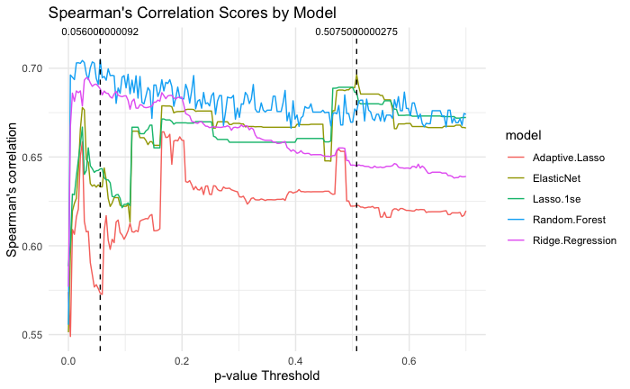

```r
# listr
load(paste0(OOL_path, "/Pvalue threshold optimization.rda"))

# Reshaping listr for plotting
listr <- as.data.frame(listr) %>%
  pivot_longer(cols = c("Lasso.1se","Ridge.Regression","ElasticNet","Adaptive.Lasso","Random.Forest"),
               names_to = "model", values_to = "speamanr")

# Find the p-value threshold with the highest Spearman's correlation score
best_threshold <- listr$pval_threshold[which.max(listr$speamanr)]
best_lm_threshold <- listr[listr$model!="Random.Forest",]$pval_threshold[which.max(listr[listr$model!="Random.Forest",]$speamanr)]

# Plot
ggplot(listr, aes(x = pval_threshold, y = speamanr, color = model)) +
  geom_line() +
  geom_vline(xintercept = best_threshold, linetype = "dashed") +
  geom_vline(xintercept = best_lm_threshold, linetype = "dashed") +
  labs(x = "p-value Threshold", y = "Spearman's correlation") +
  ggtitle("Spearman's Correlation Scores by Model") +
  theme_minimal() +
  annotate("text", x = best_threshold, y = max(listr$speamanr) + 0.01, label = best_threshold, color = "black", size = 3, vjust = -1) +
  annotate("text", x = best_lm_threshold, y = max(listr$speamanr) + 0.01, label = best_lm_threshold, color = "black", size = 3, vjust = -1)
```

## Model fitting

```r
# xxx parameter
parm=list()
parm$scale='Patient'
parm$a=0.5
npt=length(unique(Id))

# Random.Forest settings
#parm$pval_threshold=0.056
#parm$predict.model="Random.Forest"
# ElasticNet settings
#parm$pval_threshold=0.5075
#parm$predict.model="ElasticNet"
# Lasso1.se settings
parm$pval_threshold=0.5
parm$predict.model="Lasso.1se"

# Opening backend-configuration
cl <- makeSOCKcluster(detectCores())
registerDoSNOW(cl)
# Getting models and predictions
prdC=foreach(i=seq(npt),.packages = c("dplyr", "tibble")) %dopar% xxx(data.matrix(CYTOF), Yh, Id, i, parm, TRUE)
list_preds<-aggregation.of.predictions(prdC)
# Closing backend configuration
stopCluster(cl)
```

## Evaluation of results

Performances of the models

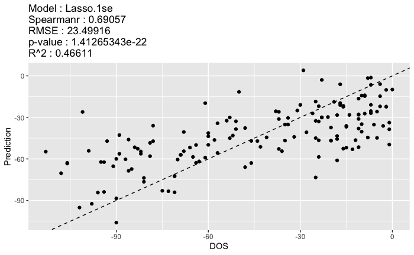

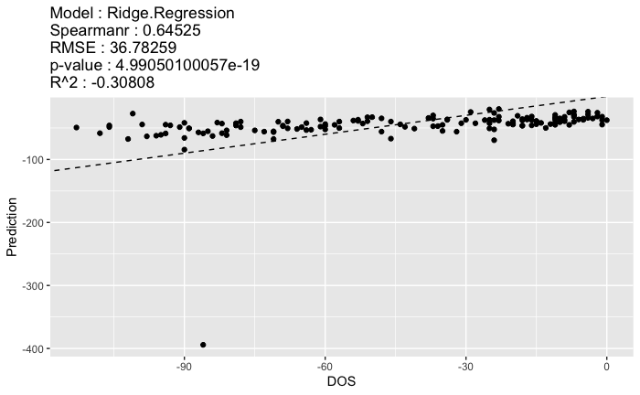

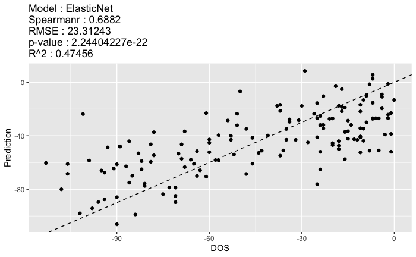

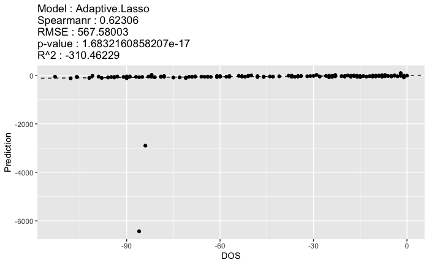

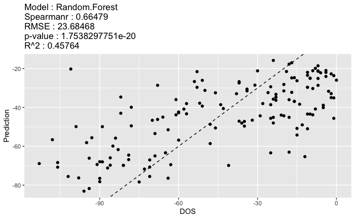

```r
require(Metrics)
# Plot function
plot.model.results <- function(y_pred, y_true, title){
  myPv = cor.test(y_true, y_pred, method = 'spearman', exact = FALSE)$p.value
  myerr = sqrt(mean((y_true-y_pred)^2))
  myr2 = 1 - sum((y_true - y_pred)^2) / sum((y_true - mean(y_true))^2)
  mycorr = cor(y_true, y_pred, method = "spearman")

  data <- data.frame(x = y_true, y = y_pred)
  p <- ggplot(data, aes(x = x, y = y)) +
        geom_point() +
        geom_abline(intercept = 0, slope = 1, linetype = "dashed") +
        labs(x = "DOS", y = "Prediction") +
        ggtitle(paste("Model : ", title,
                      "\nSpearmanr : ", round(mycorr, digits = 5),
                      "\nRMSE : ",round(myerr, digits = 5),
                      "\np-value : ",round(myPv, digits = 30),
                      "\nR^2 : ",round(myr2, digits = 5), sep=""))
  print(p)
}

# Plotting the results of the models
for (model.name in names(list_preds)){
  y_pred <- list_preds[[model.name]]
  plot.model.results(y_pred, Yh, model.name)
}
```

## Simulated drug effect visualization

Matrix of all the simulated predictions

```r
simulated.data.predictions <- c()
ID_order <- all.simulated.data[all.simulated.data$drug=="Benzylpenicillin",]$ID
for (drug in unique(all.simulated.data$drug)){
  drug.predictions <- c()
  for (i in seq(prdC)){
    drug.predictions <- rbind(drug.predictions, as.matrix(prdC[[i]][[drug]]))
  }
  col.names <- c(colnames(simulated.data.predictions), drug)
  ID_order <- intersect(ID_order, rownames(drug.predictions))
  simulated.data.predictions <- cbind(simulated.data.predictions,
                                      drug.predictions[ID_order,])
  colnames(simulated.data.predictions) <- col.names
}
head(simulated.data.predictions)
```

```
        Benzylpenicillin Cefotaxime Chlorthalidone Clotrimazole Folic acid Iodixanol   Iohexol Iopamidol Lansoprazole Maprotiline
P1_26          -29.82916  -31.25805      -28.73013    -31.19513  -28.60380 -28.30388 -29.86118 -31.34804    -26.47928   -31.10400
P1_33          -30.52957  -31.96956      -29.57829    -31.80972  -29.35794 -29.07877 -31.06639 -32.06746    -27.38376   -32.04124
P1_35          -28.75516  -30.31782      -27.81794    -30.23528  -27.31232 -27.01635 -29.26982 -30.50443    -25.14918   -30.23412
P100_29        -34.68541  -35.51230      -33.44605    -34.85066  -33.98708 -33.48279 -35.42222 -35.63689    -32.48232   -36.40947
P100_37        -25.89822  -27.28300      -24.40033    -27.04716  -24.50676 -24.05168 -26.30074 -27.52501    -22.01166   -27.67118
P100_39        -28.30898  -29.39631      -26.70926    -29.01207  -27.14435 -26.50454 -28.86946 -29.69819    -24.89316   -30.23880
        Metformin Methylpredonisolone Pravastatin Progesterone Rifabutin
P1_26   -31.73477           -29.61053   -30.28550    -33.08826 -32.48543
P1_33   -32.60680           -30.74047   -31.29952    -33.78516 -33.54277
P1_35   -31.21603           -28.67211   -29.63092    -32.39009 -32.19819
P100_29 -36.06349           -35.58614   -35.26569    -37.06837 -36.56494
P100_37 -28.35215           -26.77396   -26.80653    -29.67910 -29.04372
P100_39 -30.35897           -29.30183   -29.27418    -31.71068 -30.96475
```

Filtering the samples corresponding to DOS between DOS.inf and DOS.sup days

```r
# Adaptive.Lasso (cst) GOOD
#DOS.inf <- -94
#DOS.sup <- -74
# ElasticNet (cst) GOOD-
#DOS.inf <- -84
#DOS.sup <- -70
# Random.Forest (cst) GOOD-
#DOS.inf <- -84
#DOS.sup <- -70
# Adaptive.Lasso (prop) GOOD+
DOS.inf <- -81
DOS.sup <- -73
# ElasticNet (prop) GOOD+
#DOS.inf <- -83
#DOS.sup <- -70
# Random.Forest (prop) GOOD-
#DOS.inf <- -82
#DOS.sup <- -70
filter.ID <- subset(read_csv(paste0(OOL_path, "/outcome_OOL.csv"), show_col_types = FALSE),
                    DOS >= DOS.inf & DOS <= DOS.sup,
                    select = ID)$ID
```

Plotting the distributions of the difference between estimated TTL and estimated TTL with simulated drug effect.

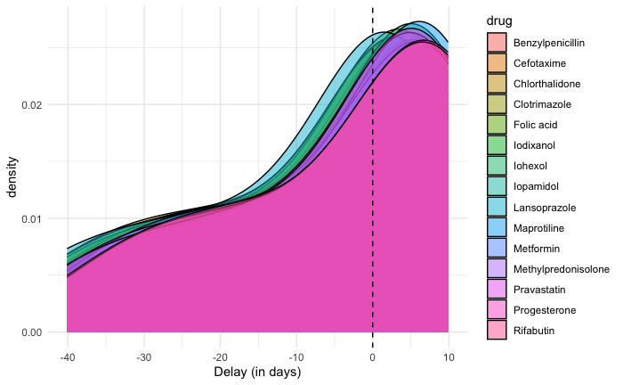

```r
# Getting the row numbers of the predictions corresponding to simulated.data
outcomes <- read_csv(paste0(OOL_path, "/outcome_OOL.csv"), show_col_types = FALSE)
outcomes <- outcomes[match(CYTOF$ID, outcomes$ID), ]
row_numbers <- which(outcomes$ID %in% ID_order)

# TTL predictions
TTL.predictions <- matrix(list_preds[[parm$predict.model]][row_numbers],
                          nrow = dim(simulated.data.predictions)[1],
                          ncol = dim(simulated.data.predictions)[2],
                          dimnames = list(ID_order, NULL))[ID_order,]

# Difference between the TTL predictions and the TTL predictions with simulated drug effect
drug.effect.on.predictions <- - (simulated.data.predictions - TTL.predictions)

# Looking at the distributions of the drug simulated effect in term of days on the TTL prediction
data <- as.data.frame(drug.effect.on.predictions[filter.ID,])

# Reshape data into long format
data_long <- gather(data, key = "drug", value = "value")

# Plot distributions
ggplot(data_long, aes(x = value, fill = drug)) +
  geom_density(alpha = 0.5) +
  xlab("Delay (in days)") +
  geom_vline(xintercept = 0, linetype = "dashed") +
  theme_minimal()
```

## Model Index

Creation of a vector of the columns that are removed when building the model.

```r
rm_cols <- c()
for (iter in seq(prdC)){
  rm_cols <- c(rm_cols, prdC[[iter]]$rm_cols)
}
rm_cols <- unique(rm_cols)
```

Creation the feature index with adaptive lasso.

```r
feature.index <- data.frame(feature = character(),
                            pval = double(),
                            mean_abs_coef = double(),
                            model_index = double(),
                            stringsAsFactors = FALSE)
cols <- colnames(CYTOF[,-c(1, rm_cols)])

for (i in seq(1, length(cols))){
  # Name of the feature
  feature <- cols[i]
  # P value based on a spearman test
  pval <- cor.test(Yh, CYTOF[[feature]], method = 'spearman', exact = FALSE)$p.value
  # Collecting all the absolute values of the coefficients of the AdaLASSO
  coefs <- c()
  for (iter in seq(prdC)){
    coefs[iter] <- abs(prdC[[iter]]$alasso_coef[i])
  }
  # Mean of the coefficients
  mean_abs_coef <- mean(coefs)
  # Adding the feature to feature.index
  feature.index <- rbind(feature.index,
                         data.frame(feature=feature,
                                    pval=pval,
                                    mean_abs_coef=mean_abs_coef,
                                    model_index=-abs(mean_abs_coef)*log10(pval),
                                    stringsAsFactors = FALSE))
}
feature.index <- feature.index %>% arrange(desc(model_index))
```

Saving feature.index

```r
save(feature.index, file=paste0(OOL_path, "/feature_index.rda"))
```

## Overlap with OOL paper

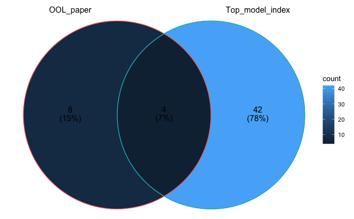

```r
# List of features
x <- list(OOL_paper = c("CD56loCD16posNK_STAT1_IFNa",
                        #"Granulocytes",
                        "CD4Tnaive_MAPKAPK2_IFNa",
                        "ncMCs_CREB_GMCSF",
                        "CD8Tem_MAPKAPK2_unstim",
                        "pDCs_STAT1_IFNa",
                        "Bcells_MAPKAPK2_LPS",
                        "CD4Tem_MAPKAPK2_unstim",
                        "CD8Tem_MAPKAPK2_IFNa",
                        #"Bcells",
                        "CD4Tem_NFkB_IL246",
                        "CD4Tcm_IkB_unstim",
                        #"mDCs_STAT6_IFNa",
                        "pDCs_STAT6_IFNa",
                        #"mDCs_MAPKAPK2_unstim",
                        "pDCs_MAPKAPK2_unstim"),
          Top_model_index = feature.index %>%
                                filter(model_index > 0.2) %>%
                                select(feature) %>%
                                unlist() %>%
                                as.character())

ggVennDiagram(x, label_alpha = 0)
```